# Netflix_EDA

```python
import pandas as pd
import numpy as np
import matplotlib.pyplot as plt
import plotly.express as px

# Display plots inside the notebook
%matplotlib inline
```

```python
import pandas as pd

df = pd.read_csv("../data/netflix_titles.csv")

df.head()
```

|  | show_id | type | title | director | cast | country | date_added | release_year | rating | duration | listed_in | description |
| --- | --- | --- | --- | --- | --- | --- | --- | --- | --- | --- | --- | --- |
| 0 | s1 | Movie | Dick Johnson Is Dead | Kirsten Johnson | NaN | United States | September 25, 2021 | 2020 | PG-13 | 90 min | Documentaries | As her father nears the end of his life, filmm... |
| 1 | s2 | TV Show | Blood & Water | NaN | Ama Qamata, Khosi Ngema, Gail Mabalane, Thaban... | South Africa | September 24, 2021 | 2021 | TV-MA | 2 Seasons | International TV Shows, TV Dramas, TV Mysteries | After crossing paths at a party, a Cape Town t... |
| 2 | s3 | TV Show | Ganglands | Julien Leclercq | Sami Bouajila, Tracy Gotoas, Samuel Jouy, Nabi... | NaN | September 24, 2021 | 2021 | TV-MA | 1 Season | Crime TV Shows, International TV Shows, TV Act... | To protect his family from a powerful drug lor... |
| 3 | s4 | TV Show | Jailbirds New Orleans | NaN | NaN | NaN | September 24, 2021 | 2021 | TV-MA | 1 Season | Docuseries, Reality TV | Feuds, flirtations and toilet talk go down amo... |
| 4 | s5 | TV Show | Kota Factory | NaN | Mayur More, Jitendra Kumar, Ranjan Raj, Alam K... | India | September 24, 2021 | 2021 | TV-MA | 2 Seasons | International TV Shows, Romantic TV Shows, TV ... | In a city of coaching centers known to train I... |

```python
# Shape of the dataset
print("Shape:", df.shape)

# Column names
print("\nColumns:")
print(df.columns)

# Data types
print("\nData Types:")
print(df.dtypes)

# First 5 rows
df.head()
```

```
Shape: (8807, 12)

Columns:
Index(['show_id', 'type', 'title', 'director', 'cast', 'country', 'date_added',
       'release_year', 'rating', 'duration', 'listed_in', 'description'],
      dtype='object')

Data Types:
show_id         object
type            object
title           object
director        object
cast            object
country         object
date_added      object
release_year     int64
rating          object
duration        object
listed_in       object
description     object
dtype: object
```

|  | show_id | type | title | director | cast | country | date_added | release_year | rating | duration | listed_in | description |
| --- | --- | --- | --- | --- | --- | --- | --- | --- | --- | --- | --- | --- |
| 0 | s1 | Movie | Dick Johnson Is Dead | Kirsten Johnson | NaN | United States | September 25, 2021 | 2020 | PG-13 | 90 min | Documentaries | As her father nears the end of his life, filmm... |
| 1 | s2 | TV Show | Blood & Water | NaN | Ama Qamata, Khosi Ngema, Gail Mabalane, Thaban... | South Africa | September 24, 2021 | 2021 | TV-MA | 2 Seasons | International TV Shows, TV Dramas, TV Mysteries | After crossing paths at a party, a Cape Town t... |
| 2 | s3 | TV Show | Ganglands | Julien Leclercq | Sami Bouajila, Tracy Gotoas, Samuel Jouy, Nabi... | NaN | September 24, 2021 | 2021 | TV-MA | 1 Season | Crime TV Shows, International TV Shows, TV Act... | To protect his family from a powerful drug lor... |
| 3 | s4 | TV Show | Jailbirds New Orleans | NaN | NaN | NaN | September 24, 2021 | 2021 | TV-MA | 1 Season | Docuseries, Reality TV | Feuds, flirtations and toilet talk go down amo... |
| 4 | s5 | TV Show | Kota Factory | NaN | Mayur More, Jitendra Kumar, Ranjan Raj, Alam K... | India | September 24, 2021 | 2021 | TV-MA | 2 Seasons | International TV Shows, Romantic TV Shows, TV ... | In a city of coaching centers known to train I... |

```python
# General information
df.info()

# Statistical summary
df.describe(include='all')
```

```
<class 'pandas.core.frame.DataFrame'>
RangeIndex: 8807 entries, 0 to 8806
Data columns (total 12 columns):
 #   Column        Non-Null Count  Dtype
---  ------        --------------  -----
 0   show_id       8807 non-null   object
 1   type          8807 non-null   object
 2   title         8807 non-null   object
 3   director      6173 non-null   object
 4   cast          7982 non-null   object
 5   country       7976 non-null   object
 6   date_added    8797 non-null   object
 7   release_year  8807 non-null   int64
 8   rating        8803 non-null   object
 9   duration      8804 non-null   object
 10  listed_in     8807 non-null   object
 11  description   8807 non-null   object
dtypes: int64(1), object(11)
memory usage: 825.8+ KB
```

|  | show_id | type | title | director | cast | country | date_added | release_year | rating | duration | listed_in | description |
| --- | --- | --- | --- | --- | --- | --- | --- | --- | --- | --- | --- | --- |
| count | 8807 | 8807 | 8807 | 6173 | 7982 | 7976 | 8797 | 8807.000000 | 8803 | 8804 | 8807 | 8807 |
| unique | 8807 | 2 | 8807 | 4528 | 7692 | 748 | 1767 | NaN | 17 | 220 | 514 | 8775 |
| top | s1 | Movie | Dick Johnson Is Dead | Rajiv Chilaka | David Attenborough | United States | January 1, 2020 | NaN | TV-MA | 1 Season | Dramas, International Movies | Paranormal activity at a lush, abandoned prope... |
| freq | 1 | 6131 | 1 | 19 | 19 | 2818 | 109 | NaN | 3207 | 1793 | 362 | 4 |
| mean | NaN | NaN | NaN | NaN | NaN | NaN | NaN | 2014.180198 | NaN | NaN | NaN | NaN |
| std | NaN | NaN | NaN | NaN | NaN | NaN | NaN | 8.819312 | NaN | NaN | NaN | NaN |
| min | NaN | NaN | NaN | NaN | NaN | NaN | NaN | 1925.000000 | NaN | NaN | NaN | NaN |
| 25% | NaN | NaN | NaN | NaN | NaN | NaN | NaN | 2013.000000 | NaN | NaN | NaN | NaN |
| 50% | NaN | NaN | NaN | NaN | NaN | NaN | NaN | 2017.000000 | NaN | NaN | NaN | NaN |
| 75% | NaN | NaN | NaN | NaN | NaN | NaN | NaN | 2019.000000 | NaN | NaN | NaN | NaN |
| max | NaN | NaN | NaN | NaN | NaN | NaN | NaN | 2021.000000 | NaN | NaN | NaN | NaN |

```python
# Count missing values
missing_values = df.isnull().sum()

print(missing_values)
```

```
show_id            0
type               0
title              0
director        2634
cast             825
country          831
date_added        10
release_year       0
rating             4
duration           3
listed_in          0
description        0
dtype: int64
```

```python
# Missing value percentage
missing_percentage = (df.isnull().sum() / len(df)) * 100

print(missing_percentage.round(2))
```

```
show_id          0.00
type             0.00
title            0.00
director        29.91
cast             9.37
country          9.44
date_added       0.11
release_year     0.00
rating           0.05
duration         0.03
listed_in        0.00
description      0.00
dtype: float64
```

```python
# Duplicate rows
duplicates = df.duplicated().sum()

print("Duplicate Rows:", duplicates)
```

```
Duplicate Rows: 0
```

```python
# Fill missing values with 'Unknown'
df['director'] = df['director'].fillna('Unknown')
df['cast'] = df['cast'].fillna('Unknown')
df['country'] = df['country'].fillna('Unknown')

# Fill rating with the most frequent value (mode)
df['rating'] = df['rating'].fillna(df['rating'].mode()[0])
```

```python
print(df.isnull().sum())
```

```
show_id          0
type             0
title            0
director         0
cast             0
country          0
date_added      10
release_year     0
rating           0
duration         3
listed_in        0
description      0
dtype: int64
```

```python
type_counts = df['type'].value_counts()

print(type_counts)
```

```
type
Movie      6131
TV Show    2676
Name: count, dtype: int64
```

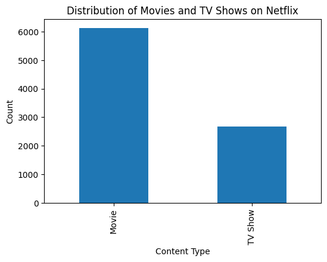

```python
plt.figure(figsize=(6,4))

type_counts.plot(kind='bar')

plt.title("Distribution of Movies and TV Shows on Netflix")
plt.xlabel("Content Type")
plt.ylabel("Count")

plt.show()
```

# Observation 1: Distribution of Movies and TV Shows

### Observation

- Netflix contains 6,131 Movies and 2,676 TV Shows.
- Movies account for approximately 70% of the total content.
- TV Shows account for approximately 30% of the total content.

### Business Insight

- Netflix's catalog is dominated by movies.
- Investing in quality TV Shows may increase user engagement and retention.

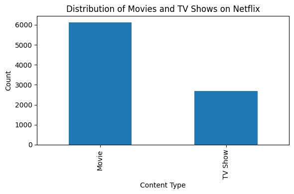

```python
plt.figure(figsize=(6,4))

type_counts.plot(kind='bar')

plt.title("Distribution of Movies and TV Shows on Netflix")
plt.xlabel("Content Type")
plt.ylabel("Count")

plt.tight_layout()

plt.savefig("../images/movies_vs_tvshows.png")

plt.show()
```

```python
release_year_counts = (
    df['release_year']
    .value_counts()
    .sort_index()
)

print(release_year_counts.tail())
```

```
release_year
2017    1032
2018    1147
2019    1030
2020     953
2021     592
Name: count, dtype: int64
```

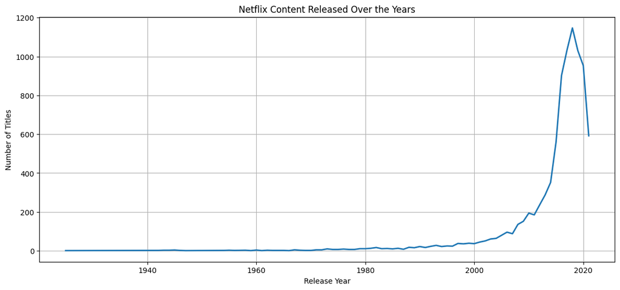

```python
plt.figure(figsize=(14,6))

plt.plot(
    release_year_counts.index,
    release_year_counts.values,
    linewidth=2
)

plt.title("Netflix Content Released Over the Years")
plt.xlabel("Release Year")
plt.ylabel("Number of Titles")

plt.grid(True)

plt.show()
```

# Observation 2: Netflix Content Released Over the Years

### Business Insight

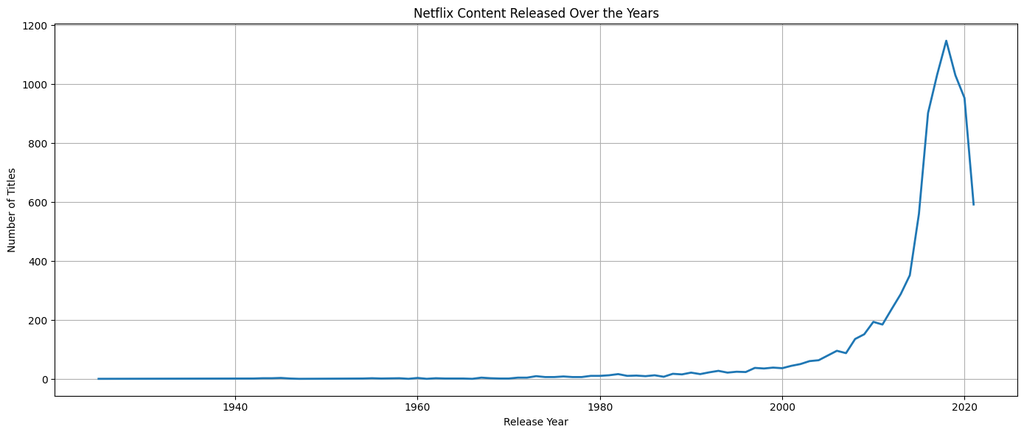

```python
plt.figure(figsize=(14,6))

plt.plot(
    release_year_counts.index,
    release_year_counts.values,
    linewidth=2
)

plt.title("Netflix Content Released Over the Years")
plt.xlabel("Release Year")
plt.ylabel("Number of Titles")

plt.grid(True)

plt.tight_layout()

plt.savefig("../images/release_year_trend.png")

plt.show()
```

```python
# Top 10 countries with the most Netflix content

top_countries = (
    df[df['country'] != 'Unknown']['country']
    .str.split(', ')
    .explode()
    .value_counts()
    .head(10)
)

print(top_countries)
```

```
country
United States     3689
India             1046
United Kingdom     804
Canada             445
France             393
Japan              318
Spain              232
South Korea        231
Germany            226
Mexico             169
Name: count, dtype: int64
```

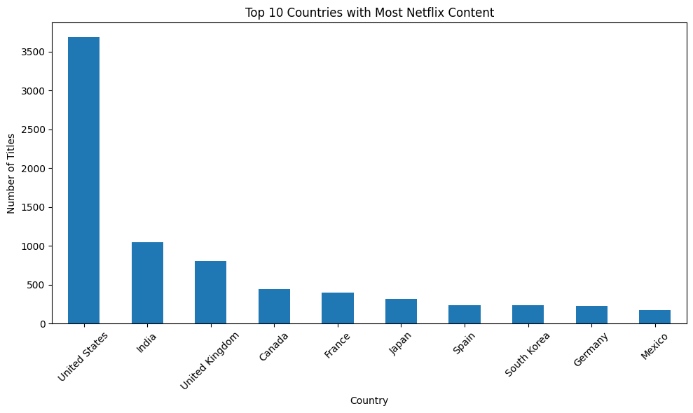

```python
plt.figure(figsize=(10,6))

top_countries.plot(kind='bar')

plt.title("Top 10 Countries with Most Netflix Content")
plt.xlabel("Country")
plt.ylabel("Number of Titles")

plt.xticks(rotation=45)

plt.tight_layout()

plt.savefig("../images/top10_countries.png")

plt.show()
```

# Observation 3: Top 10 Countries with Most Netflix Content

### Observation

- The United States has the highest number of Netflix titles.
- India is among the top contributors to Netflix's content library.
- The top 10 countries contribute a major share of Netflix's total content.

### Business Insight

- Netflix has a strong presence in the United States, reflecting its largest production market.
- India's high ranking highlights the growing demand for regional and international content.
- Expanding investments in emerging markets can help Netflix increase its global audience and diversify its content library.

```python
# Top 10 genres

top_genres = (
    df['listed_in']
    .str.split(', ')
    .explode()
    .value_counts()
    .head(10)
)

print(top_genres)
```

```
listed_in
International Movies        2752
Dramas                      2427
Comedies                    1674
International TV Shows      1351
Documentaries                869
Action & Adventure           859
TV Dramas                    763
Independent Movies           756
Children & Family Movies     641
Romantic Movies              616
Name: count, dtype: int64
```

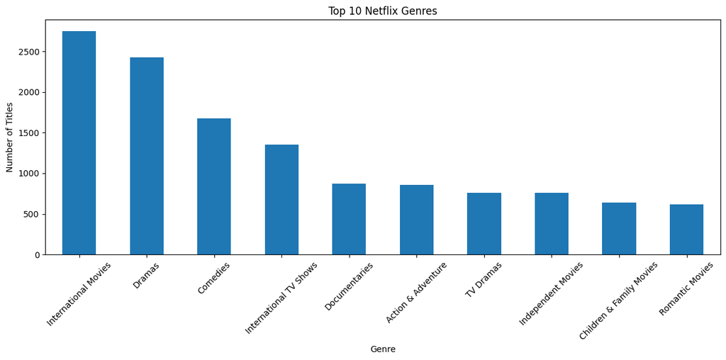

```python
plt.figure(figsize=(12,6))

top_genres.plot(kind='bar')

plt.title("Top 10 Netflix Genres")
plt.xlabel("Genre")
plt.ylabel("Number of Titles")

plt.xticks(rotation=45)

plt.tight_layout()

plt.savefig("../images/top10_genres.png")

plt.show()
```

# Observation 4: Top 10 Netflix Genres

### Observation

- Drama is one of the most popular genres on Netflix.
- International Movies and Comedies also have a significant presence.
- Netflix offers content across a wide range of genres, catering to diverse audience preferences.

### Business Insight

- Drama and International Movies attract a broad global audience.
- Netflix should continue investing in popular genres while also promoting niche genres to reach different audience segments.
- A diverse content library helps improve customer satisfaction and subscriber retention.

```python
# Count different content ratings
rating_counts = df['rating'].value_counts()

print(rating_counts.head(10))
```

```
rating
TV-MA    3211
TV-14    2160
TV-PG     863
R         799
PG-13     490
TV-Y7     334
TV-Y      307
PG        287
TV-G      220
NR         80
Name: count, dtype: int64
```

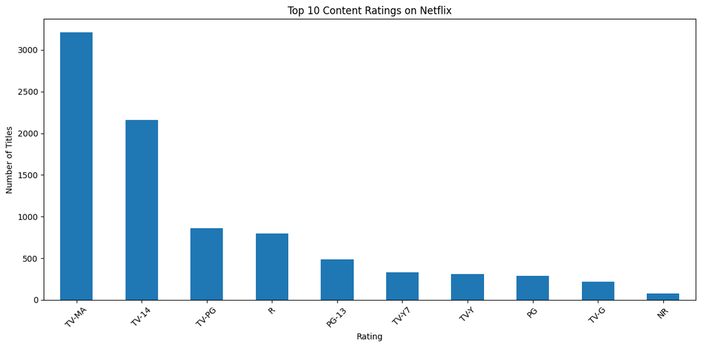

```python
plt.figure(figsize=(12,6))

rating_counts.head(10).plot(kind='bar')

plt.title("Top 10 Content Ratings on Netflix")
plt.xlabel("Rating")
plt.ylabel("Number of Titles")

plt.xticks(rotation=45)

plt.tight_layout()

plt.savefig("../images/content_ratings.png")

plt.show()
```

# Observation 5: Distribution of Content Ratings

### Observation

- TV-MA is the most common content rating on Netflix.
- TV-14 is the second most frequent rating.
- Netflix offers content suitable for different age groups, but most titles target mature audiences.

### Business Insight

- The dominance of TV-MA content indicates that Netflix primarily targets adult viewers.
- Maintaining a balanced mix of family-friendly and mature content can help attract a wider audience.
- Understanding rating distribution helps Netflix plan future content for different customer segments.

```python
top_directors = (
    df[df['director'] != 'Unknown']['director']
    .str.split(', ')
    .explode()
    .value_counts()
    .head(10)
)

print(top_directors)
```

```
director
Rajiv Chilaka          22
Jan Suter              21
Raúl Campos            19
Marcus Raboy           16
Suhas Kadav            16
Jay Karas              15
Cathy Garcia-Molina    13
Youssef Chahine        12
Martin Scorsese        12
Jay Chapman            12
Name: count, dtype: int64
```

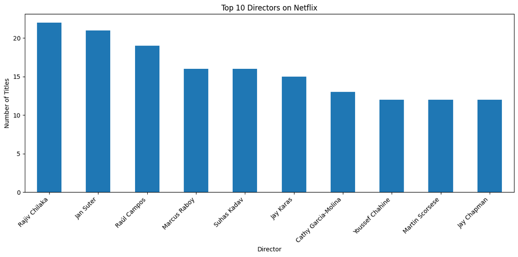

```python
plt.figure(figsize=(12,6))

top_directors.plot(kind='bar')

plt.title("Top 10 Directors on Netflix")
plt.xlabel("Director")
plt.ylabel("Number of Titles")

plt.xticks(rotation=45, ha='right')

plt.tight_layout()

plt.savefig("../images/top_directors.png")

plt.show()
```

# Observation 6: Top Directors on Netflix

### Observation

- A few directors have contributed significantly more titles than others.
- The top directors have multiple movies or TV shows available on Netflix.
- This highlights long-term collaborations and strong content partnerships.

### Business Insight

- Collaborating with successful directors can improve content quality and audience engagement.
- Netflix can use this information to strengthen relationships with high-performing creators and discover new talent.

```python
# Top 10 actors on Netflix

top_actors = (
    df[df['cast'] != 'Unknown']['cast']
    .str.split(', ')
    .explode()
    .value_counts()
    .head(10)
)

print(top_actors)
```

```
cast
Anupam Kher         43
Shah Rukh Khan      35
Julie Tejwani       33
Takahiro Sakurai    32
Naseeruddin Shah    32
Rupa Bhimani        31
Om Puri             30
Akshay Kumar        30
Yuki Kaji           29
Amitabh Bachchan    28
Name: count, dtype: int64
```

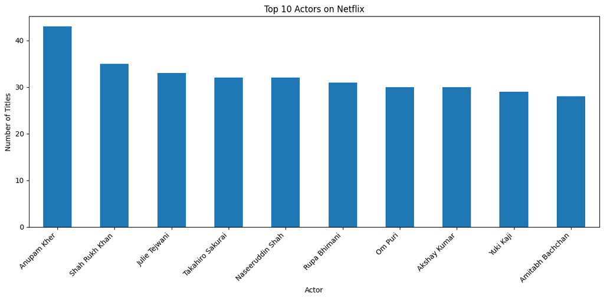

```python
plt.figure(figsize=(12,6))

top_actors.plot(kind='bar')

plt.title("Top 10 Actors on Netflix")
plt.xlabel("Actor")
plt.ylabel("Number of Titles")

plt.xticks(rotation=45, ha='right')

plt.tight_layout()

plt.savefig("../images/top_actors.png")

plt.show()
```

# Observation 7: Top Actors on Netflix

### Observation

- A small group of actors appears in a large number of Netflix titles.
- These actors have consistently contributed to popular movies and TV shows.
- Their frequent appearance reflects their popularity and strong industry presence.

### Business Insight

- Popular actors attract larger audiences and improve content visibility.
- Netflix can strengthen audience engagement by collaborating with well-known actors while also promoting emerging talent.

```python
# Select only Movies
movies = df[df['type'] == 'Movie'].copy()

# Remove rows where duration is missing
movies = movies.dropna(subset=['duration'])

# Extract numeric duration
movies['duration_minutes'] = (
    movies['duration']
    .str.extract('(\d+)')[0]
    .astype(int)
)

movies.head()
```

|  | show_id | type | title | director | cast | country | date_added | release_year | rating | duration | listed_in | description | duration_minutes |
| --- | --- | --- | --- | --- | --- | --- | --- | --- | --- | --- | --- | --- | --- |
| 0 | s1 | Movie | Dick Johnson Is Dead | Kirsten Johnson | Unknown | United States | September 25, 2021 | 2020 | PG-13 | 90 min | Documentaries | As her father nears the end of his life, filmm... | 90 |
| 6 | s7 | Movie | My Little Pony: A New Generation | Robert Cullen, José Luis Ucha | Vanessa Hudgens, Kimiko Glenn, James Marsden, ... | Unknown | September 24, 2021 | 2021 | PG | 91 min | Children & Family Movies | Equestria's divided. But a bright-eyed hero be... | 91 |
| 7 | s8 | Movie | Sankofa | Haile Gerima | Kofi Ghanaba, Oyafunmike Ogunlano, Alexandra D... | United States, Ghana, Burkina Faso, United Kin... | September 24, 2021 | 1993 | TV-MA | 125 min | Dramas, Independent Movies, International Movies | On a photo shoot in Ghana, an American model s... | 125 |
| 9 | s10 | Movie | The Starling | Theodore Melfi | Melissa McCarthy, Chris O'Dowd, Kevin Kline, T... | United States | September 24, 2021 | 2021 | PG-13 | 104 min | Comedies, Dramas | A woman adjusting to life after a loss contend... | 104 |
| 12 | s13 | Movie | Je Suis Karl | Christian Schwochow | Luna Wedler, Jannis Niewöhner, Milan Peschel, ... | Germany, Czech Republic | September 23, 2021 | 2021 | TV-MA | 127 min | Dramas, International Movies | After most of her family is murdered in a terr... | 127 |

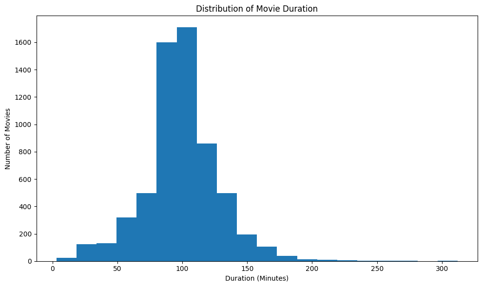

```python
plt.figure(figsize=(10,6))

plt.hist(movies['duration_minutes'], bins=20)

plt.title("Distribution of Movie Duration")
plt.xlabel("Duration (Minutes)")
plt.ylabel("Number of Movies")

plt.tight_layout()

plt.savefig("../images/movie_duration.png")

plt.show()
```

# Observation 8: Movie Duration Distribution

### Observation

- Most Netflix movies have a duration between 80 and 120 minutes.
- Very short and very long movies are less common.
- The distribution indicates that standard-length feature films dominate the platform.

### Business Insight

- Movies with a duration of around 90–120 minutes are likely to match viewer preferences.
- Understanding duration trends helps Netflix plan future content that aligns with audience viewing habits.

```python
# Remove leading/trailing spaces
df['date_added'] = df['date_added'].str.strip()

# Convert to datetime
df['date_added'] = pd.to_datetime(df['date_added'], errors='coerce')

# Create year_added column
df['year_added'] = df['date_added'].dt.year

# Count content added each year
content_added = df['year_added'].value_counts().sort_index()

print(content_added)
```

```
year_added
2008.0       2
2009.0       2
2010.0       1
2011.0      13
2012.0       3
2013.0      11
2014.0      24
2015.0      82
2016.0     429
2017.0    1188
2018.0    1649
2019.0    2016
2020.0    1879
2021.0    1498
Name: count, dtype: int64
```

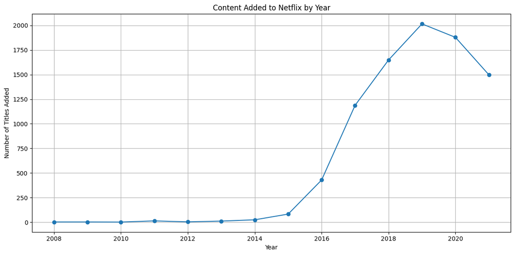

```python
plt.figure(figsize=(12,6))

plt.plot(content_added.index, content_added.values, marker='o')

plt.title("Content Added to Netflix by Year")
plt.xlabel("Year")
plt.ylabel("Number of Titles Added")

plt.grid(True)
plt.tight_layout()

plt.savefig("../images/content_added_by_year.png")

plt.show()
```

# Observation 9: Content Added to Netflix by Year

### Business Insight

- Netflix aggressively expanded its library between 2016 and 2020 to strengthen its market position.
- The slowdown after 2020 may reflect strategic content planning and production challenges.
- Monitoring yearly content additions helps Netflix optimize investment in new titles.

# Key Business Insights

1. Movies account for nearly 70% of Netflix's content library, making them the dominant content type.
2. Netflix experienced rapid growth in content production and acquisition between 2015 and 2020.
3. The United States contributes the highest number of titles, followed by India and other major content-producing countries.
4. Drama, International Movies, and Comedy are among the most popular genres available on Netflix.
5. Most Netflix content is rated TV-MA and TV-14, indicating a strong focus on mature audiences.
6. Most movies have a duration between 80 and 120 minutes, matching standard viewer preferences.
7. Netflix's diverse content catalog helps it serve audiences across different countries, languages, and age groups.

# Conclusion

This project explored the Netflix Movies and TV Shows dataset using Exploratory Data Analysis (EDA). The dataset was cleaned by handling missing values and verifying duplicate records. Various visualizations were created to understand content distribution, release trends, popular genres, countries, ratings, directors, actors, and movie durations.

The analysis revealed that Netflix primarily focuses on movies, experienced rapid content growth after 2015, and offers a diverse catalog across multiple countries and genres. These insights can help understand Netflix's content strategy and support future business decisions.

Overall, this project demonstrates practical skills in Python, Pandas, Matplotlib, data cleaning, visualization, and business insight generation.